# Interaction Terms

25 January, 2024

## Load Packages

```r
library(tidyverse)
library(lme4)
library(lmerTest)

library(emmeans)
library(ggeffects)
library(modelbased)
library(languageR)



theme_set(theme(plot.title = element_text(size = 9), panel.grid.major = element_blank(),
    panel.grid.minor = element_blank(), legend.position = "bottom"))

theme_set(theme_classic())

colpalet <- c("#0077FF", "#DC3220")

load("data.RData")
```

## Modelling terms

- response = outcome variable = dependent variable
- fixed effect = predictor variable = independent variable
- random effect = group-level effect = individual-specific effect

## Preference

- emmeans:: for pairwise comparisons of variable contrasts.
- ggeffects:: for visualisation of interactions
- modelbased:: for extracting interaction effect
- ggplot2:: + modelbased:: for highly customized visualisation

## Two predictor variables

- Categorical x Categorical
- Continuous x Categorical
- Continuous x Continuous

## Data Analytic Flow

**1) Model statistics**

model <- lm(Y ~ A * B, data = data)

summary(model)

car::Anova(model, type = “III”)

**2) Report interaction statistics**

emmeans(model, pairwise ~ A | B)

ggemmeans(model, terms = c(“A”, “B”))

estimate_contrasts(model, contrast = “A”, at = “B”)

estimate_slopes(model, trend = “A”, at = “B”)

**3) Visualising interaction**

emmeans(model, pairwise ~ A | B) %>% plot(comparisons = T)

ggemmeans(model, terms = c(“A”, “B”)) %>% plot()

estimate_slopes(model, trend = “A”, at = “B”) %>% plot()

## Data

```r
head(analyse_cue[sample(1:nrow(analyse_cue)), ])
```

|  | ...1 | id | cbid | t1.x | t2.x | CodingWindow | NON | ...13 | t1.y | t2.y | CHI | MOT | initiator | gender | pid | age | age_grp | cues | labels | initiate_type | cue_presence |
| --- | --- | --- | --- | --- | --- | --- | --- | --- | --- | --- | --- | --- | --- | --- | --- | --- | --- | --- | --- | --- | --- |
| 2675 | 539 | 13 | 13 | 467.161 | 470.161 | coding window | 0 | 412 | 470.130 | 470.914 | 0 | 재밌어? | mother | M | P04 | 7.230128 | 0 | TactileCue_Object | Infant and mother touch/hold object | non-speech | 1 |
| 6441 | 1305 | 25 | 34 | 1586.493 | 1589.493 | check coding window | 0 | 1379 | 1589.475 | 1596.222 | 어@b 우@b 음@b 아@b 음@b 아우@b 아@b 아@b 우@b. | 0 | child | M | P09 | 14.197417 | 1 | GesturalCue | 0 | non-speech | 0 |
| 2657 | 536 | 13 | 10 | 406.214 | 409.214 | coding window | 0 | 409 | 409.190 | 410.734 | 0 | xxx 건가? | mother | M | P04 | 7.230128 | 0 | LookCue | Infant and mother look object/action/face/body part(s) | non-speech | 1 |
| 9117 | 1846 | 32 | 58 | 2869.492 | 2872.492 | coding window | 0 | 1905 | 2872.625 | 2873.630 | 0 | ads-exp 이 볼펜으로 할까요? | mother | F | P10 | 12.591634 | 1 | LookCue | 0 | non-speech | 0 |
| 9693 | 1962 | 35 | 26 | 1492.060 | 1511.002 | coding window | 0. | 325 | 1491.793 | 1492.054 | 0 | 꼭@o@wp. | mother | M | P11 | 7.340000 | 0 | PointingCue | 0 | non-speech | 0 |
| 2039 | 412 | 11 | 19 | 487.110 | 495.772 | coding window | 0. | 19 | 486.860 | 487.158 | 0 | xxx. | mother | M | P04 | 12.000000 | 1 | TactileCue_Human | 0 | non-speech | 0 |

## Model Statistics

```r
summary(mod2_cue) %>%
    print()
```

```
## Generalized linear mixed model fit by maximum likelihood (Laplace
##   Approximation) [glmerMod]
##  Family: binomial  ( logit )
## Formula: cue_presence ~ (cues + initiator + age + gender)^2 + (1 + cbid |
##     id)
##    Data: analyse_cue
## Control: glmerControl(optimizer = "bobyqa")
##
##      AIC      BIC   logLik deviance df.resid
##   7089.8   7277.7  -3518.9   7037.8    10169
##
## Scaled residuals:
##     Min      1Q  Median      3Q     Max
## -2.7419 -0.2933 -0.0919  0.5344 20.4785
##
## Random effects:
##  Groups Name        Variance  Std.Dev. Corr
##  id     (Intercept) 0.5884735 0.76712
##         cbid        0.0007769 0.02787  -0.87
## Number of obs: 10195, groups:  id, 34
##
## Fixed effects:
##                                       Estimate Std. Error z value Pr(>|z|)
## (Intercept)                           -2.31428    0.64607  -3.582 0.000341 ***
## cuesLookCue                            3.71156    0.58699   6.323 2.56e-10 ***
## cuesPointingCue                       -5.32241    1.74395  -3.052 0.002274 **
## cuesTactileCue_Human                   1.57164    0.61853   2.541 0.011056 *
## cuesTactileCue_Object                  3.42903    0.58534   5.858 4.68e-09 ***
## initiatormother                       -0.11629    0.44142  -0.263 0.792207
## age                                   -0.09336    0.03266  -2.858 0.004257 **
## genderM                               -0.72254    0.51467  -1.404 0.160348
## cuesLookCue:initiatormother            0.25401    0.42711   0.595 0.552034
## cuesPointingCue:initiatormother        0.89848    1.17588   0.764 0.444815
## cuesTactileCue_Human:initiatormother   0.13881    0.45199   0.307 0.758764
## cuesTactileCue_Object:initiatormother  0.28182    0.42627   0.661 0.508533
## cuesLookCue:age                        0.05612    0.02770   2.026 0.042775 *
## cuesPointingCue:age                    0.13757    0.05552   2.478 0.013220 *
## cuesTactileCue_Human:age              -0.01529    0.02937  -0.521 0.602563
## cuesTactileCue_Object:age              0.06202    0.02765   2.243 0.024902 *
## cuesLookCue:genderM                   -0.04123    0.34562  -0.119 0.905041
## cuesPointingCue:genderM                0.92315    1.14413   0.807 0.419747
## cuesTactileCue_Human:genderM           0.51587    0.36498   1.413 0.157531
## cuesTactileCue_Object:genderM         -0.12848    0.34460  -0.373 0.709264
## initiatormother:age                   -0.02508    0.01031  -2.432 0.015026 *
## initiatormother:genderM                0.30402    0.17021   1.786 0.074079 .
## age:genderM                            0.03814    0.02162   1.764 0.077748 .
## ---
## Signif. codes:  0 '***' 0.001 '**' 0.01 '*' 0.05 '.' 0.1 ' ' 1
## optimizer (bobyqa) convergence code: 1 (bobyqa -- maximum number of function evaluations exceeded)
## Model failed to converge with max|grad| = 0.0332271 (tol = 0.002, component 1)
```

## Model Statistics

```r
car::Anova(mod2_cue, type = "III") %>%
    print()
```

```
## Analysis of Deviance Table (Type III Wald chisquare tests)
##
## Response: cue_presence
##                     Chisq Df Pr(>Chisq)
## (Intercept)       12.8312  1  0.0003409 ***
## cues             101.0722  4  < 2.2e-16 ***
## initiator          0.0694  1  0.7922068
## age                8.1708  1  0.0042569 **
## gender             1.9709  1  0.1603482
## cues:initiator     1.0710  4  0.8988428
## cues:age          38.1183  4  1.059e-07 ***
## cues:gender       12.2250  4  0.0157541 *
## initiator:age      5.9134  1  0.0150261 *
## initiator:gender   3.1902  1  0.0740795 .
## age:gender         3.1114  1  0.0777476 .
## ---
## Signif. codes:  0 '***' 0.001 '**' 0.01 '*' 0.05 '.' 0.1 ' ' 1
```

## Analysing Interactions

emmeans::emmeans(model, pairwise ~ varA | varB, type = “response”)

ggeffects::ggemmeans(model, terms = c(“varB”, “varA”))

modelbased::estimate_contrasts(model, contrast = “varA”, at = “varB”) or modelbased::estimate_slopes(model, trend = “varA”, at = “varB”)

## Categorical x Categorical

**Cues x Sex**

```r
unique(analyse_cue$cues)
```

```
## [1] "GesturalCue"       "LookCue"           "PointingCue"
## [4] "TactileCue_Human"  "TactileCue_Object"
```

```r
unique(analyse_cue$gender)
```

```
## [1] "M" "F"
```

## Categorical x Categorical

**Report interaction statistics:** **emmeans**

```r
emmeans(mod2_cue, pairwise ~ cues | gender, type = "response")$emmeans %>%
    data.frame() %>%
    mutate_if(is.numeric, funs(round(., 3)))
```

|  | cues | gender | prob | SE | df | asymp.LCL | asymp.UCL |
| --- | --- | --- | --- | --- | --- | --- | --- |
| 1 | GesturalCue | F | 0.018 | 0.006 | Inf | 0.010 | 0.034 |
| 2 | LookCue | F | 0.671 | 0.037 | Inf | 0.595 | 0.739 |
| 3 | PointingCue | F | 0.001 | 0.001 | Inf | 0.000 | 0.009 |
| 4 | TactileCue_Human | F | 0.072 | 0.014 | Inf | 0.049 | 0.104 |
| 5 | TactileCue_Object | F | 0.630 | 0.039 | Inf | 0.552 | 0.703 |
| 6 | GesturalCue | M | 0.019 | 0.005 | Inf | 0.011 | 0.031 |
| 7 | LookCue | M | 0.663 | 0.030 | Inf | 0.602 | 0.719 |
| 8 | PointingCue | M | 0.003 | 0.002 | Inf | 0.001 | 0.010 |
| 9 | TactileCue_Human | M | 0.115 | 0.016 | Inf | 0.087 | 0.150 |
| 10 | TactileCue_Object | M | 0.602 | 0.032 | Inf | 0.538 | 0.662 |

## Categorical x Categorical

**Report interaction statistics:** **emmeans**

```r
emmeans(mod2_cue, pairwise ~ cues | gender, type = "response")$contrasts %>%
    data.frame() %>%
    select(-df, -null) %>%
    mutate_if(is.numeric, funs(round(., 3)))
```

|  | contrast | gender | odds.ratio | SE | z.ratio | p.value |
| --- | --- | --- | --- | --- | --- | --- |
| 1 | GesturalCue / LookCue | F | 0.009 | 0.003 | -15.192 | 0.000 |
| 2 | GesturalCue / PointingCue | F | 16.340 | 18.116 | 2.520 | 0.086 |
| 3 | GesturalCue / TactileCue_Human | F | 0.244 | 0.081 | -4.273 | 0.000 |
| 4 | GesturalCue / TactileCue_Object | F | 0.011 | 0.003 | -14.649 | 0.000 |
| 5 | LookCue / PointingCue | F | 1773.240 | 1902.098 | 6.974 | 0.000 |
| 6 | LookCue / TactileCue_Human | F | 26.498 | 4.778 | 18.174 | 0.000 |
| 7 | LookCue / TactileCue_Object | F | 1.197 | 0.147 | 1.460 | 0.588 |
| 8 | PointingCue / TactileCue_Human | F | 0.015 | 0.016 | -3.891 | 0.001 |
| 9 | PointingCue / TactileCue_Object | F | 0.001 | 0.001 | -6.808 | 0.000 |
| 10 | TactileCue_Human / TactileCue_Object | F | 0.045 | 0.008 | -17.305 | 0.000 |

[output cut: 10 more lines]

## Categorical x Categorical

**Report interaction statistics:** **ggemmeans**

```r
ggemmeans(mod2_cue, terms = c("gender", "cues")) %>%
    mutate_if(is.numeric, funs(round(., 3)))
```

|  | x | predicted | std.error | conf.low | conf.high | group |
| --- | --- | --- | --- | --- | --- | --- |
| 1 | F | 0.018 | 0.325 | 0.010 | 0.034 | GesturalCue |
| 2 | F | 0.671 | 0.168 | 0.595 | 0.739 | LookCue |
| 3 | F | 0.001 | 1.079 | 0.000 | 0.009 | PointingCue |
| 4 | F | 0.072 | 0.209 | 0.049 | 0.104 | TactileCue_Human |
| 5 | F | 0.630 | 0.166 | 0.552 | 0.703 | TactileCue_Object |
| 6 | M | 0.019 | 0.269 | 0.011 | 0.031 | GesturalCue |

## Categorical x Categorical

**Report interaction statistics:** **modelbased**

```r
estimate_contrasts(mod2_cue, contrast = "cues", at = "gender") %>%
    select(-df) %>%
    mutate_if(is.numeric, funs(round(., 3))) %>%
    sample_n(nrow(.))
```

| Level1 | Level2 | gender | Difference | CI_low | CI_high | SE | z | p |
| --- | --- | --- | --- | --- | --- | --- | --- | --- |
| GesturalCue | TactileCue_Object | F | -4.507 | -5.371 | -3.644 | 0.308 | -14.649 | 0.000 |
| GesturalCue | TactileCue_Human | F | -1.410 | -2.336 | -0.484 | 0.330 | -4.273 | 0.000 |
| PointingCue | TactileCue_Object | F | -7.301 | -10.312 | -4.291 | 1.072 | -6.808 | 0.000 |
| LookCue | TactileCue_Human | F | 3.277 | 2.771 | 3.783 | 0.180 | 18.174 | 0.000 |
| LookCue | TactileCue_Object | M | 0.267 | -0.007 | 0.541 | 0.098 | 2.731 | 0.012 |
| LookCue | TactileCue_Human | M | 2.720 | 2.346 | 3.094 | 0.133 | 20.420 | 0.000 |
| TactileCue_Human | TactileCue_Object | F | -3.098 | -3.600 | -2.595 | 0.179 | -17.305 | 0.000 |
| GesturalCue | TactileCue_Object | M | -4.379 | -5.092 | -3.666 | 0.254 | -17.228 | 0.000 |
| GesturalCue | LookCue | F | -4.687 | -5.553 | -3.821 | 0.309 | -15.192 | 0.000 |
| LookCue | PointingCue | F | 7.481 | 4.470 | 10.492 | 1.073 | 6.974 | 0.000 |

[output cut: 10 more lines]

## Categorical x Categorical

**Report interaction statistics:** **emmeans vs modelbased**

```r
emmeans(mod2_cue, pairwise ~ cues | gender)$contrasts %>%
    data.frame() %>%
    select(-df) %>%
    mutate_if(is.numeric, funs(round(., 3)))
```

|  | contrast | gender | estimate | SE | z.ratio | p.value |
| --- | --- | --- | --- | --- | --- | --- |
| 1 | GesturalCue - LookCue | F | -4.687 | 0.309 | -15.192 | 0.000 |
| 2 | GesturalCue - PointingCue | F | 2.794 | 1.109 | 2.520 | 0.086 |
| 3 | GesturalCue - TactileCue_Human | F | -1.410 | 0.330 | -4.273 | 0.000 |
| 4 | GesturalCue - TactileCue_Object | F | -4.507 | 0.308 | -14.649 | 0.000 |
| 5 | LookCue - PointingCue | F | 7.481 | 1.073 | 6.974 | 0.000 |
| 6 | LookCue - TactileCue_Human | F | 3.277 | 0.180 | 18.174 | 0.000 |
| 7 | LookCue - TactileCue_Object | F | 0.179 | 0.123 | 1.460 | 0.588 |
| 8 | PointingCue - TactileCue_Human | F | -4.204 | 1.080 | -3.891 | 0.001 |
| 9 | PointingCue - TactileCue_Object | F | -7.301 | 1.072 | -6.808 | 0.000 |
| 10 | TactileCue_Human - TactileCue_Object | F | -3.098 | 0.179 | -17.305 | 0.000 |

[output cut: 10 more lines]

```r
estimate_contrasts(mod2_cue, contrast = "cues", at = "gender") %>%
    select(-df) %>%
    mutate_if(is.numeric, funs(round(., 3)))
```

| Level1 | Level2 | gender | Difference | CI_low | CI_high | SE | z | p |
| --- | --- | --- | --- | --- | --- | --- | --- | --- |
| GesturalCue | LookCue | F | -4.687 | -5.553 | -3.821 | 0.309 | -15.192 | 0.000 |
| GesturalCue | LookCue | M | -4.646 | -5.361 | -3.930 | 0.255 | -18.230 | 0.000 |
| GesturalCue | PointingCue | F | 2.794 | -0.318 | 5.906 | 1.109 | 2.520 | 0.023 |
| GesturalCue | PointingCue | M | 1.870 | -0.045 | 3.786 | 0.682 | 2.741 | 0.012 |
| GesturalCue | TactileCue_Human | F | -1.410 | -2.336 | -0.484 | 0.330 | -4.273 | 0.000 |
| GesturalCue | TactileCue_Human | M | -1.926 | -2.677 | -1.174 | 0.268 | -7.195 | 0.000 |
| GesturalCue | TactileCue_Object | F | -4.507 | -5.371 | -3.644 | 0.308 | -14.649 | 0.000 |
| GesturalCue | TactileCue_Object | M | -4.379 | -5.092 | -3.666 | 0.254 | -17.228 | 0.000 |
| LookCue | PointingCue | F | 7.481 | 4.470 | 10.492 | 1.073 | 6.974 | 0.000 |
| LookCue | PointingCue | M | 6.516 | 4.715 | 8.317 | 0.642 | 10.157 | 0.000 |

[output cut: 10 more lines]

## Interaction statistics

**Categorical x Categorical:**

|  | predicted/estimated means | means contrasts |
| --- | --- | --- |
| emmeans() | yes | yes |
| ggemmeans() | yes | no |
| estimate_contrasts() | no | yes |

## Categorical x Categorical

**Visualising interaction:** **emmeans**

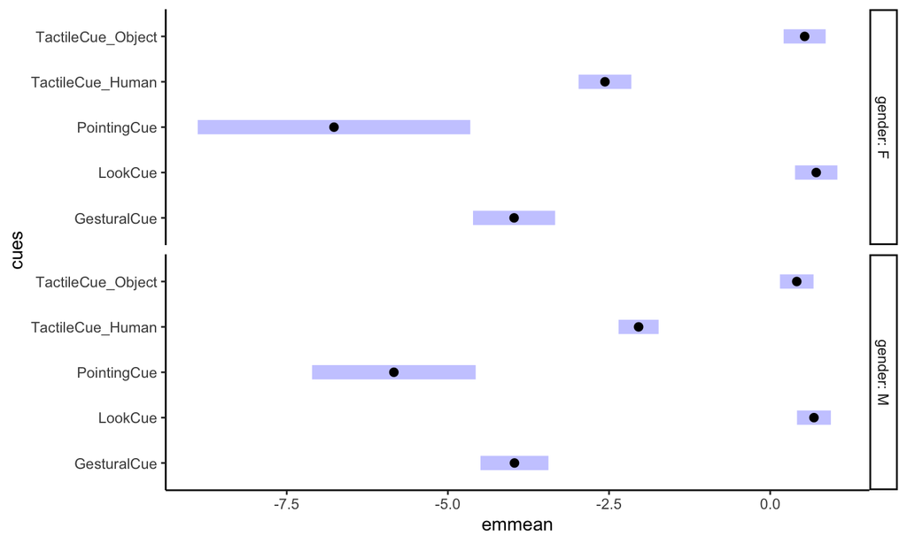

```r
emmeans::emmeans(mod2_cue, pairwise ~ cues | gender)$emmeans %>%
    plot()
```

## Categorical x Categorical

**Visualising interaction:** **emmeans**

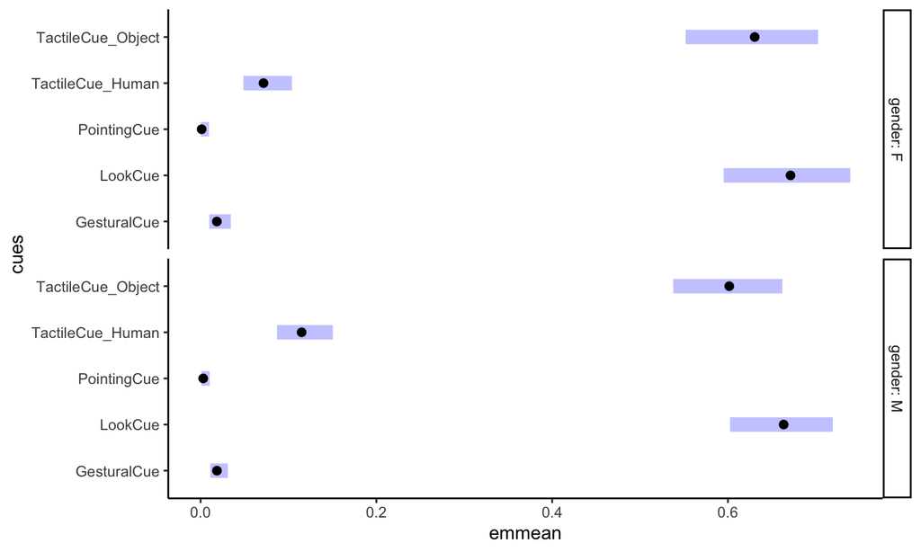

```r
emmeans::emmeans(mod2_cue, pairwise ~ cues | gender, type = "response")$emmeans %>%
    plot()
```

## Categorical x Categorical

**Visualising interaction:** **emmeans**

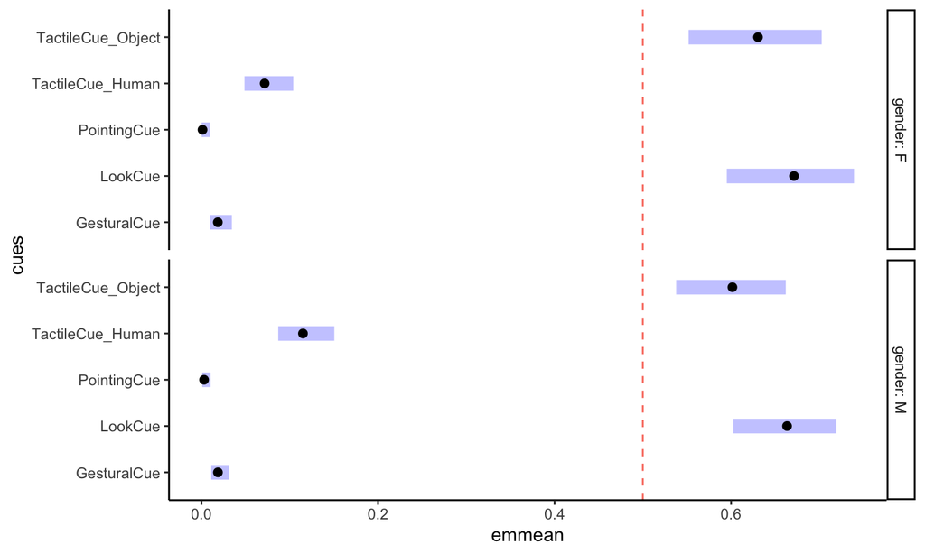

```r
emmeans::emmeans(mod2_cue, pairwise ~ cues | gender, type = "response")$emmeans %>%
    plot() + geom_vline(xintercept = 0.5, col = "salmon", linetype = "dashed")
```

## Categorical x Categorical

**Visualising interaction:** **emmeans**

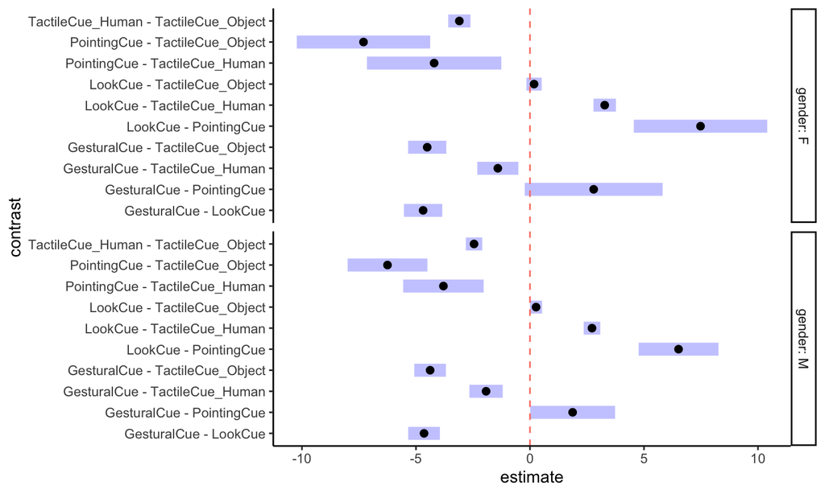

```r
emmeans::emmeans(mod2_cue, pairwise ~ cues | gender)$contrasts %>%
    plot() + geom_vline(xintercept = 0, col = "salmon", linetype = "dashed")
```

## Categorical x Categorical

**Visualising interaction:** **ggeffects**

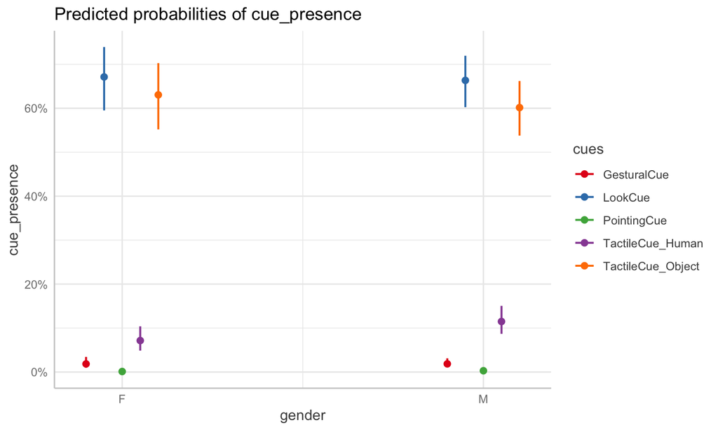

```r
ggeffects::ggemmeans(mod2_cue, terms = c("gender", "cues")) %>%
    plot()
```

## Categorical x Categorical

**Visualising interaction:** **modelbased**

```r
modelbased::estimate_contrasts(mod2_cue, contrast = "cues", at = "gender") %>%
    plot()
```

```
## Error in .data_plot_estimate_contrasts(x, data): Please provide the estimated means data obtained via 'estimate_means()'.
```

```r
estimate_contrasts(mod2_cue, contrast = "cues", at = "gender") %>%
    plot(estimate_means(mod2_cue, contrast = "cues", at = "gender"))
```

```
## Error in `[.data.frame`(data_means, , y_name): undefined columns selected
```

```r
estimate_means(mod2_cue, contrast = "cues", at = "gender") %>%
    plot(estimate_contrasts(mod2_cue, contrast = "cues", at = "gender"))
```

```
## Error: `show_data` can only be some of 'points', 'boxplot', 'violin'. Check
##   spelling.
```

## Interaction statistics

**Categorical x Categorical:**

|  | predicted/estimated means | means contrasts | visualisation easy? |
| --- | --- | --- | --- |
| emmeans() | yes | yes | yes |
| ggemmeans() | yes | no | yes |
| estimate_contrasts() | no | yes | no |

## Interaction statistics

**Categorical x Categorical:**

|  | predicted/estimated means | means contrasts | visualisation easy? | visualisation informative? |
| --- | --- | --- | --- | --- |
| emmeans() | yes | yes | yes | good |
| ggemmeans() | yes | no | yes | ok |
| estimate_contrasts() | no | yes | no | NA |

## Continuous x Categorical

**Age x Cues**

```r
unique(analyse_cue$age) %>%
    sort()
```

```
##  [1]  6.065833  6.295817  7.230128  7.340000  7.460112  7.492967  9.460153
##  [8]  9.525863  9.690137  9.755847 12.000000 12.493070 12.591634 13.131686
## [15] 13.690220 13.755929 14.197417 14.493111 15.558841 16.098893 25.340000
## [22] 25.427627 25.460482 25.526192 25.559046 26.034000 26.427647 26.789051
## [29] 27.066264 27.657652 28.164849 30.789133
```

```r
unique(analyse_cue$cues)
```

```
## [1] "GesturalCue"       "LookCue"           "PointingCue"
## [4] "TactileCue_Human"  "TactileCue_Object"
```

## Continuous x Categorical

**Report interaction statistics:** **emmeans**

```r
emmeans::emmeans(mod2_cue, pairwise ~ cues | age, type = "response")$emmeans %>%
    data.frame() %>%
    mutate_if(is.numeric, funs(round(., 3)))
```

|  | cues | age | prob | SE | df | asymp.LCL | asymp.UCL |
| --- | --- | --- | --- | --- | --- | --- | --- |
| 1 | GesturalCue | 15.116 | 0.019 | 0.004 | Inf | 0.012 | 0.029 |
| 2 | LookCue | 15.116 | 0.667 | 0.027 | Inf | 0.613 | 0.718 |
| 3 | PointingCue | 15.116 | 0.002 | 0.001 | Inf | 0.000 | 0.007 |
| 4 | TactileCue_Human | 15.116 | 0.091 | 0.012 | Inf | 0.070 | 0.118 |
| 5 | TactileCue_Object | 15.116 | 0.616 | 0.028 | Inf | 0.559 | 0.670 |

age was collapsed at the mean!

## Continuous x Categorical

**Report interaction statistics:** **emmeans**

```r
emmeans::emmeans(mod2_cue, pairwise ~ cues | age, type = "response")$contrasts %>%
    data.frame() %>%
    select(-df, -null) %>%
    mutate_if(is.numeric, funs(round(., 3)))
```

|  | contrast | age | odds.ratio | SE | z.ratio | p.value |
| --- | --- | --- | --- | --- | --- | --- |
| 1 | GesturalCue / LookCue | 15.1159940250123 | 0.009 | 0.002 | -20.828 | 0.000 |
| 2 | GesturalCue / PointingCue | 15.1159940250123 | 10.299 | 7.428 | 3.233 | 0.011 |
| 3 | GesturalCue / TactileCue_Human | 15.1159940250123 | 0.189 | 0.045 | -6.989 | 0.000 |
| 4 | GesturalCue / TactileCue_Object | 15.1159940250123 | 0.012 | 0.003 | -19.879 | 0.000 |
| 5 | LookCue / PointingCue | 15.1159940250123 | 1094.848 | 757.141 | 10.120 | 0.000 |
| 6 | LookCue / TactileCue_Human | 15.1159940250123 | 20.056 | 2.512 | 23.944 | 0.000 |
| 7 | LookCue / TactileCue_Object | 15.1159940250123 | 1.250 | 0.108 | 2.580 | 0.074 |
| 8 | PointingCue / TactileCue_Human | 15.1159940250123 | 0.018 | 0.013 | -5.737 | 0.000 |
| 9 | PointingCue / TactileCue_Object | 15.1159940250123 | 0.001 | 0.001 | -9.799 | 0.000 |
| 10 | TactileCue_Human / TactileCue_Object | 15.1159940250123 | 0.062 | 0.008 | -22.325 | 0.000 |

- perhaps ok, if the goal is to control for age rather than understanding age-related effect
- especially when the relationship between continuous variable and response variable is linear and well-studied
- but then, adding continuous variable as covariate (i.e., standalone predictor without interaction terms) could achieve the same goal, unless still suspect interactions of some sort

## Continuous x Categorical

**Report interaction statistics:** **ggeffects**

```r
ggeffects::ggemmeans(mod2_cue, terms = c("age [all]", "cues")) %>%
    data.frame() %>%
    mutate_if(is.numeric, funs(round(., 3))) %>%
    sample_n(nrow(.)/5) %>%
    arrange(x)
```

| x | predicted | std.error | conf.low | conf.high | group |
| --- | --- | --- | --- | --- | --- |
| 6.07 | 0.040 | 0.302 | 0.022 | 0.070 | GesturalCue |
| 6.30 | 0.724 | 0.166 | 0.655 | 0.785 | LookCue |
| 6.30 | 0.001 | 0.925 | 0.000 | 0.007 | PointingCue |
| 7.34 | 0.036 | 0.279 | 0.021 | 0.060 | GesturalCue |
| 7.34 | 0.181 | 0.177 | 0.135 | 0.238 | TactileCue_Human |
| 7.34 | 0.718 | 0.158 | 0.651 | 0.776 | LookCue |
| 7.34 | 0.001 | 0.889 | 0.000 | 0.007 | PointingCue |
| 7.46 | 0.035 | 0.277 | 0.021 | 0.059 | GesturalCue |
| 9.46 | 0.001 | 0.823 | 0.000 | 0.007 | PointingCue |
| 9.69 | 0.703 | 0.141 | 0.642 | 0.758 | LookCue |

[output cut: 22 more lines]

showed us the predicted proportion of group (i.e., cues) across x (i.e., age) as a continuous variable!

## Continuous x Categorical

**Report interaction statistics:** **modelbased**

```r
modelbased::estimate_slopes(mod2_cue, trend = "age", at = "cues") %>%
    mutate_if(is.numeric, funs(round(., 3)))
```

| cues | Coefficient | SE | CI | CI_low | CI_high | z | df_error | p |
| --- | --- | --- | --- | --- | --- | --- | --- | --- |
| GesturalCue | -0.087 | 0.029 | 0.95 | -0.143 | -0.031 | -3.026 | Inf | 0.002 |
| LookCue | -0.031 | 0.012 | 0.95 | -0.054 | -0.007 | -2.573 | Inf | 0.010 |
| PointingCue | 0.051 | 0.050 | 0.95 | -0.047 | 0.148 | 1.019 | Inf | 0.308 |
| TactileCue_Human | -0.102 | 0.016 | 0.95 | -0.134 | -0.071 | -6.341 | Inf | 0.000 |
| TactileCue_Object | -0.025 | 0.012 | 0.95 | -0.048 | -0.002 | -2.092 | Inf | 0.036 |

showed us statistics *at* cues and the associated age *trend*. great for summarising the relations.

## Interaction statistics

**Continuous x Categorical:**

|  | predicted/estimated means | means contrasts | coefficient |
| --- | --- | --- | --- |
| emmeans() | yes, continuous variable as collapsed mean | yes | no |
| ggemmeans() | yes, continuous stays continuous | no | no |
| estimate_slopes() | no | no | yes |

## Continuous x Categorical

**Visualising interaction:** **emmeans**

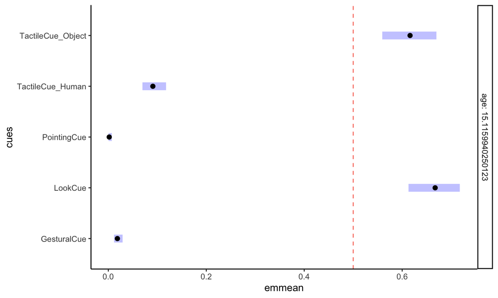

```r
emmeans::emmeans(mod2_cue, pairwise ~ cues | age, type = "response")$emmeans %>%
    plot() + geom_vline(xintercept = 0.5, col = "salmon", linetype = "dashed")
```

## Continuous x Categorical

**Visualising interaction:** **emmeans**

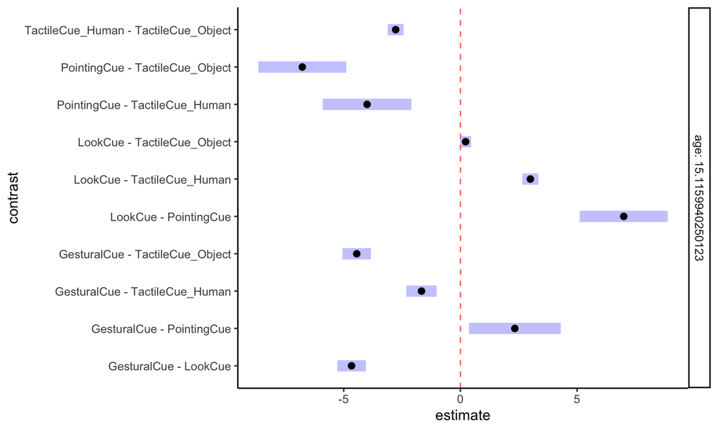

```r
emmeans::emmeans(mod2_cue, pairwise ~ cues | age)$contrasts %>%
    plot() + geom_vline(xintercept = 0, col = "salmon", linetype = "dashed")
```

## Continuous x Categorical

**Visualising interaction:** **ggeffects**

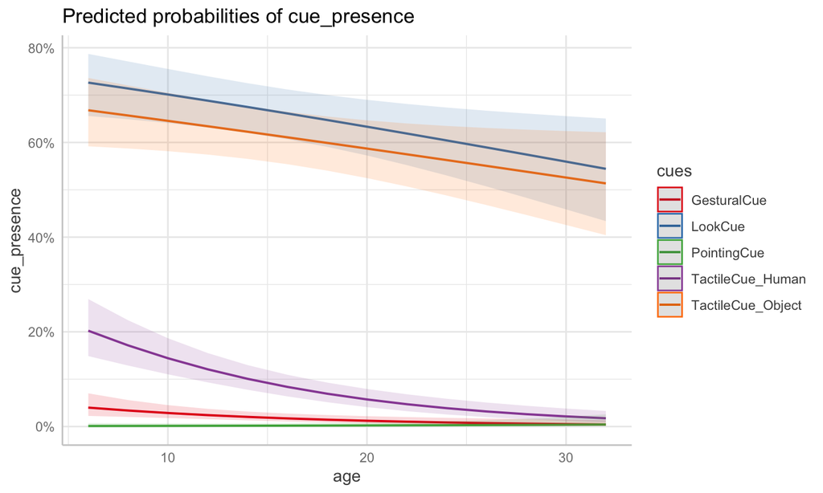

```r
ggeffects::ggemmeans(mod2_cue, terms = c("age", "cues")) %>%
    plot()
```

## Continuous x Categorical

**Visualising interaction:** **modelbased**

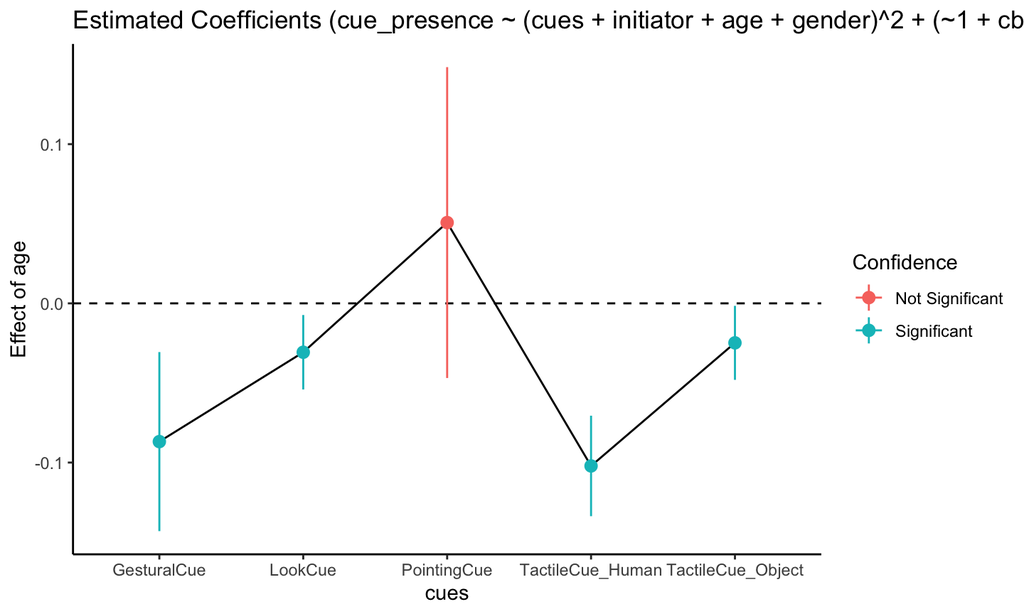

```r
modelbased::estimate_slopes(mod2_cue, trend = "age", at = "cues") %>%
    plot()
```

## Interaction statistics

**Continuous x Categorical:**

|  | predicted/estimated means | means contrasts | coefficient | visualisation easy? |
| --- | --- | --- | --- | --- |
| emmeans() | yes, continuous variable as collapsed mean | yes | no | yes |
| ggemmeans() | yes, continuous stays continuous | no | no | yes |
| estimate_slopes() | no | no | yes | yes |

## Interaction statistics

**Continuous x Categorical:**

|  | predicted/estimated means | means contrasts | coefficient | visualisation easy? | visualisation informative? |
| --- | --- | --- | --- | --- | --- |
| emmeans() | yes, continuous variable as collapsed mean | yes | no | yes | no effect related to continuous variable |
| ggemmeans() | yes, continuous stays continuous | no | no | yes | show curve |
| estimate_slopes() | no | no | yes | yes | show effect/coefficient/slope |

## Variable: Continuous or Categorical?

```r
head(n_initiated[sample(1:nrow(n_initiated)), ])
```

| id | age | age_grp | gender | initiator | n |
| --- | --- | --- | --- | --- | --- |
| 2 | 9.460153 | 0 | M | child | 18 |
| 7 | 9.690137 | 0 | F | child | 6 |
| 18 | 26.789051 | 2 | M | mother | 58 |
| 26 | 25.460482 | 2 | M | mother | 94 |
| 19 | 26.034000 | 2 | M | child | 11 |
| 15 | 14.493111 | 1 | F | child | 23 |

## Variable: Continuous or Categorical?

**Age as continuous variable**

```r
(car::Anova(mod2_init_age_cont, 3) %>%
    data.frame() %>%
    mutate_if(is.numeric, funs(round(., 3))))[6, ]
```

|  | Chisq | Df | Pr..Chisq. |
| --- | --- | --- | --- |
| age:initiator | 5.563 | 1 | 0.018 |

**Age as categorical variable**

```r
(car::Anova(mod2_init_age_cat, 3) %>%
    data.frame() %>%
    mutate_if(is.numeric, funs(round(., 3))))[6, ]
```

|  | Chisq | Df | Pr..Chisq. |
| --- | --- | --- | --- |
| age_grp:initiator | 5.923 | 2 | 0.052 |

## Variable: Continuous or Categorical?

**Age as continuous variable**

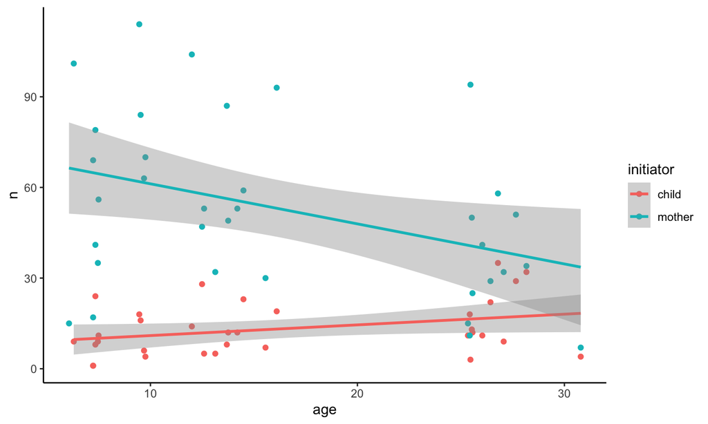

```r
ggplot(n_initiated, aes(y = n, x = age, col = initiator)) + geom_point() +
    geom_smooth(method = "lm", formula = y ~ x)
```

## Variable: Continuous or Categorical?

**Age as categorical variable**

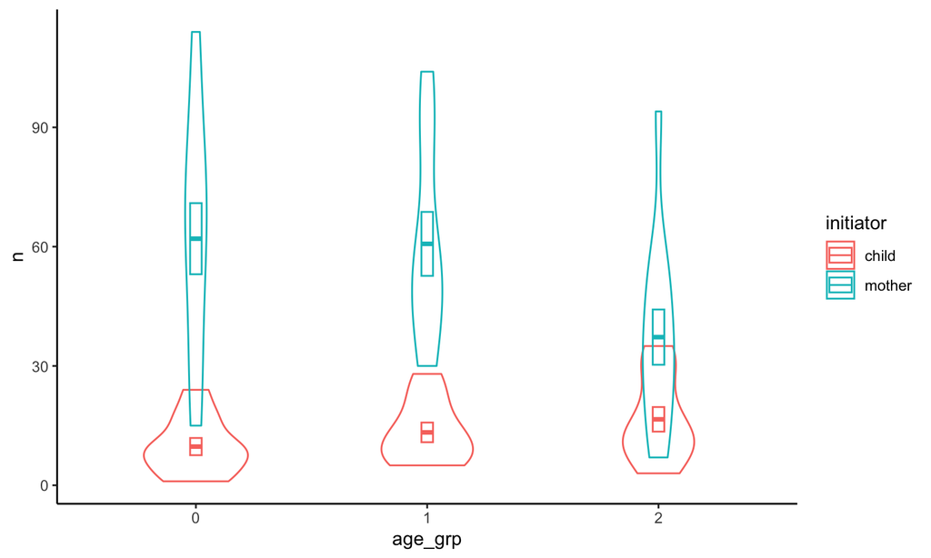

```r
ggplot(n_initiated, aes(y = n, x = age_grp, col = initiator)) +
    geom_violin(position = position_dodge(0), alpha = 0) + stat_summary(geom = "crossbar",
    fun.data = "mean_se", width = 0.05)
```

## Continuous x Continuous

**Utterance length x Word length**

```r
unique(full$phrase_s) %>%
    sample(10)
```

```
##  [1]  5.533333 13.112219  9.939024 14.911475  6.733803 13.636066  8.746667
##  [8] 11.261501  7.446682 12.185996
```

```r
unique(full$word_s) %>%
    sample(10)
```

```
##  [1] 1.593246 1.759701 1.918360 1.789446 1.561584 1.676361 1.676719 1.727805
##  [9] 1.691126 1.668203
```

## Continuous x Continuous

**Report interaction statistics:** **emmeans**

```r
emmeans(mod_full, pairwise ~ phrase_s | word_s, type = "response")$emmeans %>%
    data.frame() %>%
    mutate_if(is.numeric, funs(round(., 3)))
```

|  | phrase_s | word_s | emmean | SE | df | lower.CL | upper.CL |
| --- | --- | --- | --- | --- | --- | --- | --- |
| 1 | 10.191 | 1.764 | 0.635 | 0.001 | 125.559 | 0.633 | 0.637 |

```r
emmeans(mod_full, pairwise ~ phrase_s | word_s)$contrasts %>%
    data.frame() %>%
    mutate_if(is.numeric, funs(round(., 3)))
```

|  | contrast | word_s | estimate | SE | df | z.ratio | p.value |
| --- | --- | --- | --- | --- | --- | --- | --- |
| 1 | (nothing) | 1.764 | NA | NA | NA | NA | NA |

## Continuous x Continuous

**Report interaction statistics:** **ggeffects**

```r
ggeffects::ggemmeans(mod_full, terms = c("phrase_s", "word_s")) %>%
    data.frame() %>%
    mutate_if(is.numeric, funs(round(., 3)))
```

| x | predicted | std.error | conf.low | conf.high | group |
| --- | --- | --- | --- | --- | --- |
| 0 | 0.771 | 0.006 | 0.761 | 0.782 | 1.64 |
| 0 | 0.751 | 0.005 | 0.742 | 0.760 | 1.76 |
| 0 | 0.729 | 0.006 | 0.718 | 0.739 | 1.89 |
| 5 | 0.707 | 0.002 | 0.702 | 0.711 | 1.64 |
| 5 | 0.694 | 0.002 | 0.690 | 0.698 | 1.76 |
| 5 | 0.680 | 0.003 | 0.674 | 0.686 | 1.89 |
| 10 | 0.642 | 0.002 | 0.639 | 0.645 | 1.64 |
| 10 | 0.637 | 0.001 | 0.635 | 0.639 | 1.76 |
| 10 | 0.632 | 0.001 | 0.629 | 0.634 | 1.89 |
| 15 | 0.577 | 0.005 | 0.568 | 0.586 | 1.64 |

[output cut: 5 more lines]

```r
ggeffects::ggemmeans(mod_full, terms = c("word_s", "phrase_s")) %>%
    data.frame() %>%
    mutate_if(is.numeric, funs(round(., 3)))
```

| x | predicted | std.error | conf.low | conf.high | group |
| --- | --- | --- | --- | --- | --- |
| 1.0 | 0.734 | 0.007 | 0.720 | 0.748 | 6.88 |
| 1.0 | 0.663 | 0.007 | 0.650 | 0.676 | 10.19 |
| 1.0 | 0.592 | 0.011 | 0.571 | 0.614 | 13.51 |
| 1.5 | 0.694 | 0.002 | 0.689 | 0.698 | 6.88 |
| 1.5 | 0.645 | 0.003 | 0.639 | 0.650 | 10.19 |
| 1.5 | 0.595 | 0.005 | 0.585 | 0.605 | 13.51 |
| 2.0 | 0.653 | 0.003 | 0.647 | 0.659 | 6.88 |
| 2.0 | 0.626 | 0.002 | 0.622 | 0.630 | 10.19 |
| 2.0 | 0.599 | 0.002 | 0.594 | 0.604 | 13.51 |

## Continuous x Continuous

**Report interaction statistics:** **modelbased**

```
modelbased::estimate_slopes(mod_full, trend = "word_s", at = "phrase_s") -> mod_full_wrd_phr
```

| phrase_s | Coefficient | SE | CI | CI_low | CI_high | t | df_error | p |
| --- | --- | --- | --- | --- | --- | --- | --- | --- |
| 4.692 | -0.110 | 0.014 | 0.95 | -0.137 | -0.083 | -8.112 | 200.964 | 0.000 |
| 6.336 | -0.088 | 0.011 | 0.95 | -0.110 | -0.067 | -8.154 | 197.237 | 0.000 |
| 7.979 | -0.066 | 0.009 | 0.95 | -0.084 | -0.049 | -7.521 | 193.857 | 0.000 |
| 9.622 | -0.045 | 0.008 | 0.95 | -0.061 | -0.029 | -5.470 | 195.340 | 0.000 |
| 11.265 | -0.023 | 0.009 | 0.95 | -0.041 | -0.005 | -2.526 | 202.304 | 0.012 |
| 12.909 | -0.001 | 0.011 | 0.95 | -0.024 | 0.021 | -0.127 | 208.341 | 0.899 |
| 14.552 | 0.020 | 0.014 | 0.95 | -0.008 | 0.048 | 1.431 | 211.554 | 0.154 |
| 16.195 | 0.042 | 0.017 | 0.95 | 0.008 | 0.076 | 2.420 | 213.058 | 0.016 |
| 17.839 | 0.064 | 0.021 | 0.95 | 0.023 | 0.104 | 3.076 | 213.747 | 0.002 |
| 19.482 | 0.085 | 0.024 | 0.95 | 0.038 | 0.133 | 3.533 | 214.054 | 0.001 |

```
modelbased::estimate_slopes(mod_full, trend = "phrase_s", at = "word_s")  -> mod_full_phr_wrd
```

| word_s | Coefficient | SE | CI | CI_low | CI_high | t | df_error | p |
| --- | --- | --- | --- | --- | --- | --- | --- | --- |
| 1.298 | -0.017 | 0.001 | 0.95 | -0.020 | -0.015 | -13.405 | 227.057 | 0 |
| 1.381 | -0.016 | 0.001 | 0.95 | -0.019 | -0.014 | -14.470 | 228.203 | 0 |
| 1.464 | -0.015 | 0.001 | 0.95 | -0.017 | -0.013 | -15.816 | 229.065 | 0 |
| 1.547 | -0.014 | 0.001 | 0.95 | -0.016 | -0.013 | -17.501 | 228.894 | 0 |
| 1.630 | -0.013 | 0.001 | 0.95 | -0.014 | -0.012 | -19.485 | 225.898 | 0 |
| 1.713 | -0.012 | 0.001 | 0.95 | -0.013 | -0.011 | -21.323 | 216.923 | 0 |
| 1.796 | -0.011 | 0.001 | 0.95 | -0.012 | -0.010 | -21.696 | 201.031 | 0 |
| 1.879 | -0.010 | 0.001 | 0.95 | -0.011 | -0.009 | -19.259 | 186.530 | 0 |
| 1.962 | -0.009 | 0.001 | 0.95 | -0.010 | -0.008 | -15.006 | 181.349 | 0 |
| 2.045 | -0.008 | 0.001 | 0.95 | -0.009 | -0.006 | -10.928 | 182.726 | 0 |

## Interaction statistics

**Continuous x Continuous:**

|  | predicted/estimated means | means contrasts | coefficient |
| --- | --- | --- | --- |
| emmeans() | yes, but quirky | no | no |
| ggemmeans() | yes, continuous stays continuous | no | no |
| estimate_slopes() | no | no | yes |

## Continuous x Continuous

**Visualising interaction:** **emmeans**

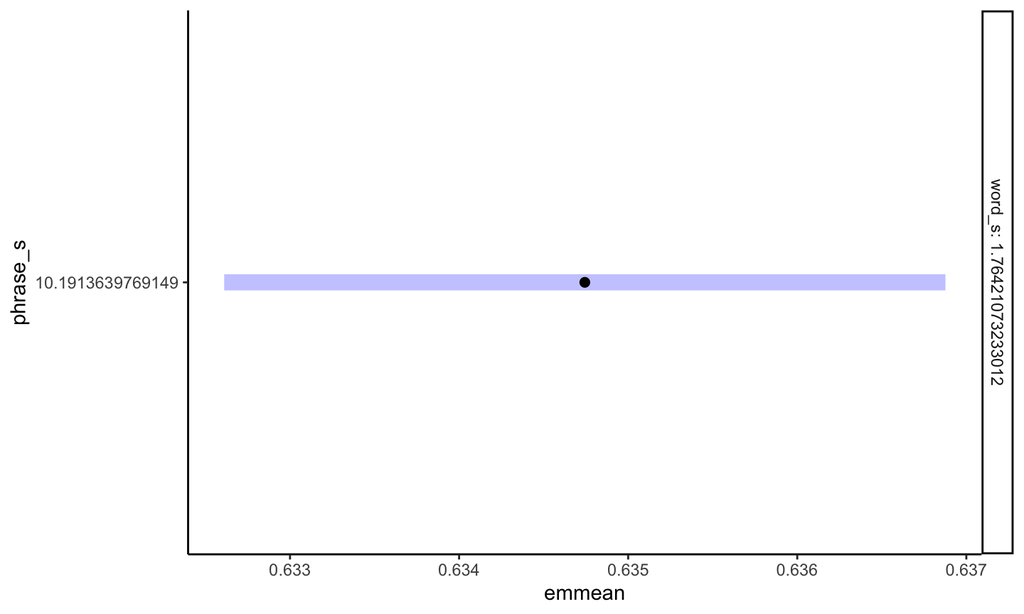

```r
emmeans(mod_full, pairwise ~ phrase_s | word_s, type = "response")$emmeans %>%
    plot()
```

## Continuous x Continuous

**Visualising interaction:** **emmeans**

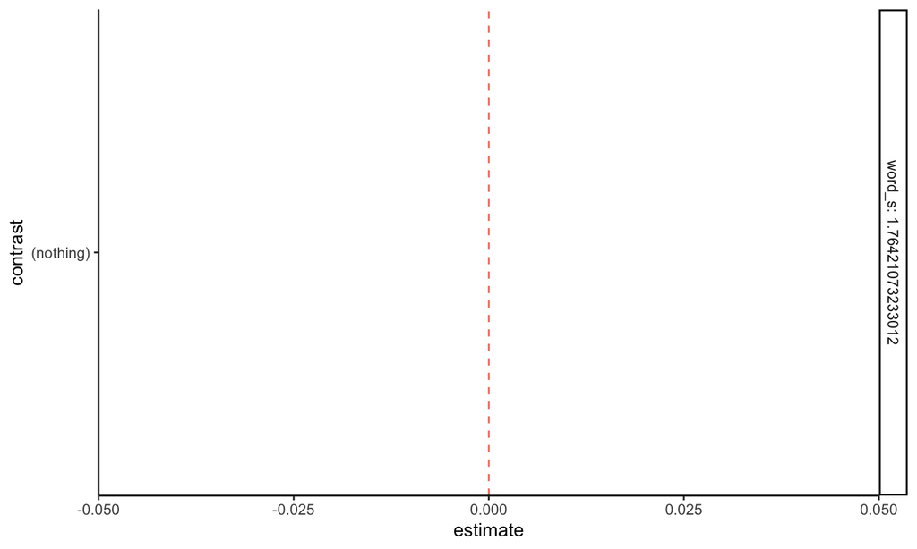

```r
emmeans(mod_full, pairwise ~ phrase_s | word_s)$contrasts %>%
    plot() + geom_vline(xintercept = 0, col = "salmon", linetype = "dashed")
```

## Continuous x Continuous

**Visualising interaction:** **ggeffects**

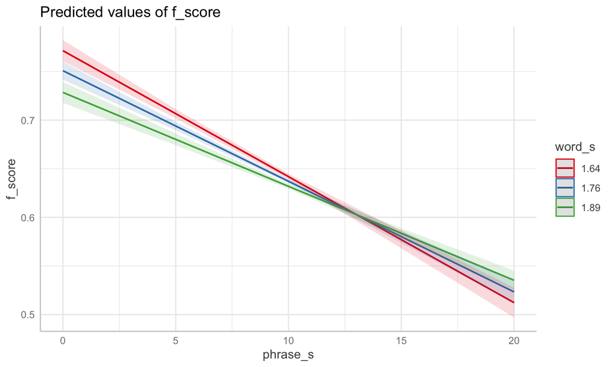

```r
ggeffects::ggemmeans(mod_full, terms = c("phrase_s", "word_s")) %>%
    plot()
```

## Continuous x Continuous

**Visualising interaction:** **ggeffects**

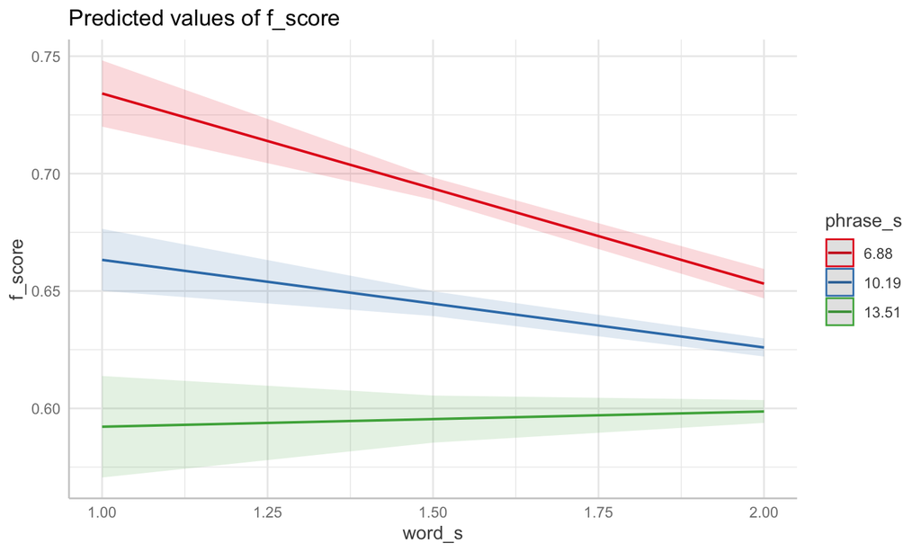

```r
ggeffects::ggemmeans(mod_full, terms = c("word_s", "phrase_s")) %>%
    plot()
```

## Continuous x Continuous

**Report interaction statistics:** **modelbased**

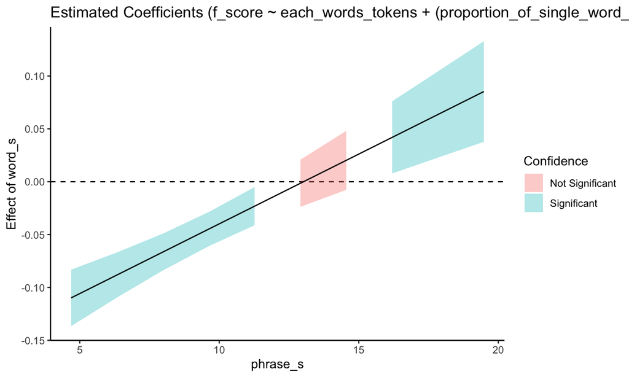

```r
mod_full_wrd_phr %>%
    plot() -> gwrd_phr
gwrd_phr
```

## Continuous x Continuous

**Report interaction statistics:** **modelbased**

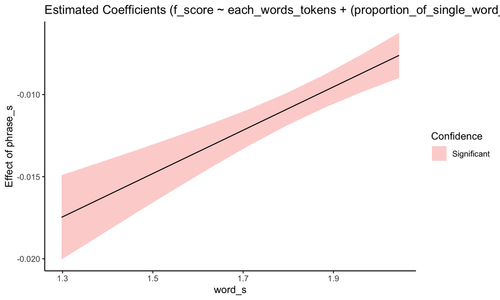

```r
mod_full_phr_wrd %>%
    plot() -> phr_wrd
phr_wrd
```

## Interaction statistics

**Continuous x Continuous:**

|  | predicted/estimated means | means contrasts | coefficient | visualisation informative? |
| --- | --- | --- | --- | --- |
| emmeans() | yes, but quirky | no | no | no |
| ggemmeans() | yes, continuous stays continuous | no | no | show curves with third variable cross-sectional |
| estimate_slopes() | no | no | yes | show effect/coefficient/slope across full range of third variable |

## Continuous x Continuous

- ggeffect show curves, i.e., how variable X predicts outcome Z, with a third variable, Y, cross-sectionally
- ggeffect show relation between of variable X and outcome Z or variable Y and outcome Z, but not simultaneously
- requires 2 graphs to visualise interactions between X and Y against Z

## Continuous x Continuous

alternative:

- estimate_means() +
- geom_contour_filled() or
- geom_raster() or
- geom_tile()

## Contour map

```
estimate_means(mod_full,
               at = c("phrase_s",  "word_s")) -> means_utt_word
```

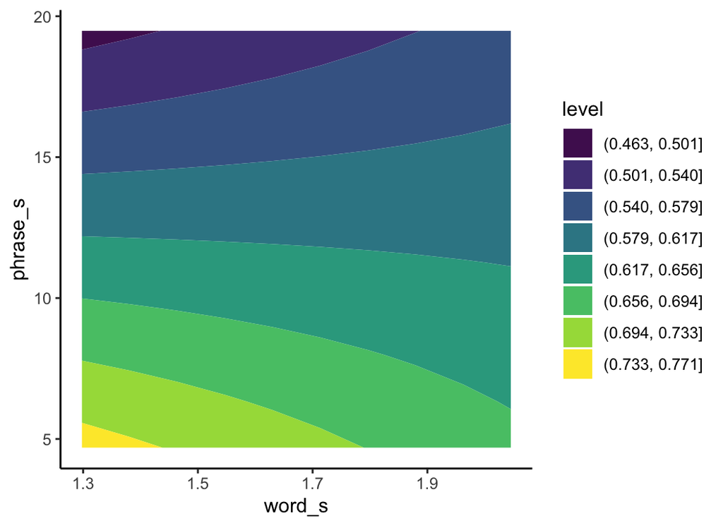

```r
ggplot(means_utt_word, aes(y = phrase_s, x = word_s)) + geom_contour_filled(aes(z = Mean),
    alpha = 0.95, bins = 8) -> gcon
gcon
```

## geom_contour vs modelbased::

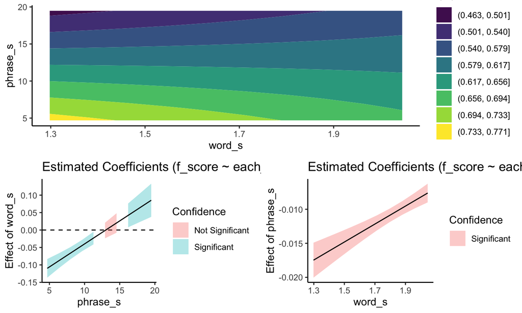

```r
ggpubr::ggarrange(gcon, ggpubr::ggarrange(gwrd_phr, phr_wrd),
    nrow = 2)
```

## How about 3-way interactions?

```
geom_contour_filled() + facet_wrap()

geom_raster() + facet_wrap()

geom_tile() + facet_wrap()
```

## Contour map

**Utt x Word:** **Data**

```r
head(dataq3[sample(1:nrow(dataq3)), ])
```

|  | f_score | algo | type | Unit | each_words_tokens | proportion_of_single_word_utt | phrase_s | word_s | each_mattr | each_entropy | proportion_of_hapaxes_words | infant | predicted |
| --- | --- | --- | --- | --- | --- | --- | --- | --- | --- | --- | --- | --- | --- |
| 101 | 0.5734 | puddle | ADS | Phonetic | 327 | 0.3013699 | 9.479452 | 1.730000 | 0.8788644 | 0.018382319 | 0.4128440 | S7 | 0.5815478 |
| 2243 | 0.6353 | puddle | ADS_CF | Phonetic | 2271 | 0.3060345 | 10.202586 | 1.730896 | 0.9198585 | 0.011505619 | 0.2659621 | Sko6568 | 0.6291010 |
| 2500 | 0.6523 | dibs_l | ADS_CF | Syllable | 2653 | 0.1929825 | 13.061404 | 1.915729 | 0.9401816 | 0.007034977 | 0.2683754 | Sko6667 | 0.6538148 |
| 2762 | 0.7402 | tp_ab_f | ADS_CF | Syllable | 2039 | 0.2622951 | 13.636066 | 1.774317 | 0.9241005 | 0.010311459 | 0.2623835 | Sko6757 | 0.7371723 |
| 2404 | 0.6886 | tp_ab_b | ADS_CF | Syllable | 2480 | 0.1186441 | 18.522034 | 1.969009 | 0.9238057 | 0.009902430 | 0.2782258 | Sko6626 | 0.6772097 |
| 771 | 0.6215 | dibs_l | CDS | Phonetic | 2900 | 0.2298578 | 7.446682 | 1.678686 | 0.8648097 | 0.012101679 | 0.1527586 | S9 | 0.6570432 |

## Contour map

**Utt x Word:**

**Model Statistics**

```r
(car::Anova(mod_full, type = "III") %>%
    data.frame() %>%
    mutate_if(is.numeric, funs(round(., 3))))["phrase_s:word_s:algo",
    ]
```

|  | Chisq | Df | Pr..Chisq. |
| --- | --- | --- | --- |
| phrase_s:word_s:algo | 17.989 | 8 | 0.021 |

## Contour map

**Utt x Word:**

**Interaction Statistics**

```
estimate_means(mod_full,
                at = c("phrase_s", "word_s","algo")
) -> est_gmf_utt_word

estimate_slopes(mod_full,
  trend = "phrase_s",
  at = c("word_s","algo")
) -> gmf_utt_word

estimate_slopes(mod_full,
  trend = "word_s",
  at = c("phrase_s","algo")
) -> gmf_word_utt
```

## Contour map

**Utt x Word:**

**Interaction Statistics**

```
estimate_means(mod_full,
                at = c("phrase_s", "word_s","algo")
) -> est_gmf_utt_word
```

```r
head(est_gmf_utt_word[sample(1:nrow(est_gmf_utt_word)), ])
```

|  | phrase_s | word_s | algo | Mean | SE | CI_low | CI_high |
| --- | --- | --- | --- | --- | --- | --- | --- |
| 285 | 11.265490 | 1.962371 | tp_ab_f | 0.6626643 | 0.004514490 | 0.6538114 | 0.6715172 |
| 394 | 9.622194 | 2.045433 | tp_re_b | 0.6304671 | 0.006604767 | 0.6175155 | 0.6434187 |
| 873 | 7.978899 | 1.879308 | ag | 0.6985158 | 0.004659746 | 0.6893782 | 0.7076533 |
| 538 | 16.195376 | 1.547059 | dibs_ph | 0.5995200 | 0.018275371 | 0.5636832 | 0.6353567 |
| 480 | 19.481967 | 1.879308 | tp_ab_b | 0.6084105 | 0.012969989 | 0.5829767 | 0.6338443 |
| 392 | 6.335603 | 2.045433 | tp_re_b | 0.6463411 | 0.010707180 | 0.6253450 | 0.6673372 |

## Contour map

**Utt x Word**

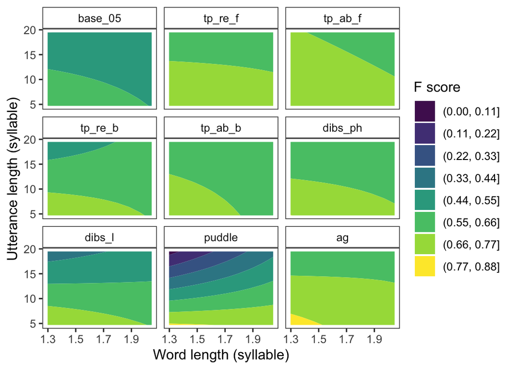

```r
ggplot(est_gmf_utt_word, aes(y = phrase_s, x = word_s)) + geom_contour_filled(aes(z = Mean),
    alpha = 0.95, bins = 8) + facet_wrap(~algo) + labs(fill = "F score",
    colour = "Significance:Utt_len.Word_len") + theme_test() +
    theme(legend.position = "right", strip.background = element_rect(fill = "white")) +
    xlab("Word length (syllable)") + ylab("Utterance length (syllable)")
```

## Contour map

**Utt x Word**

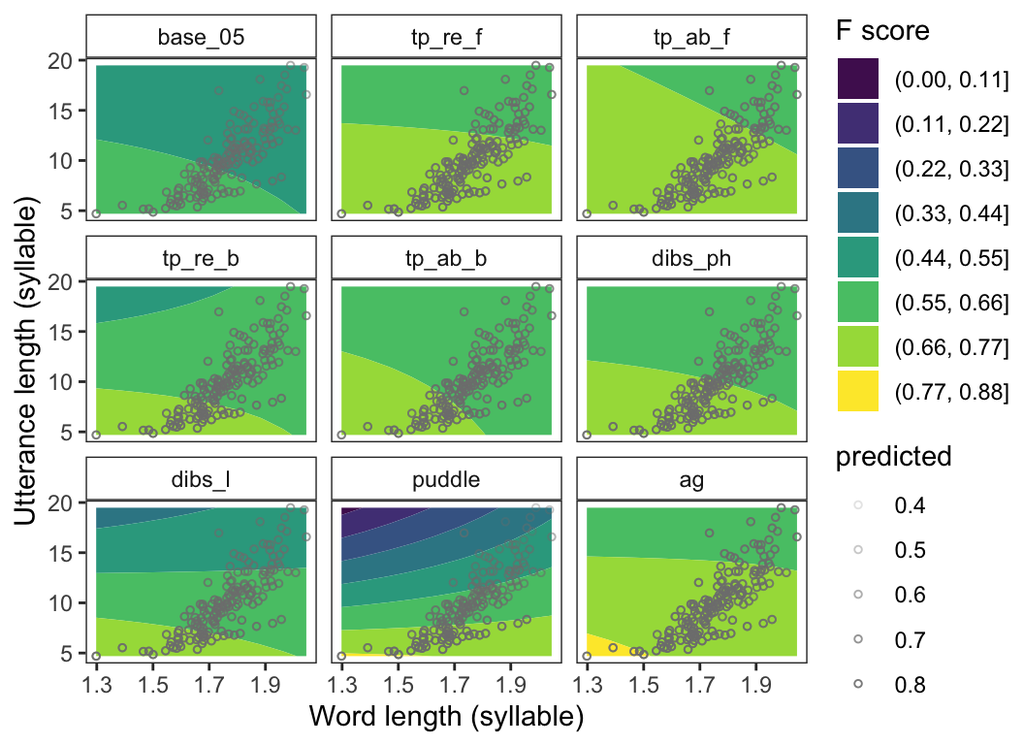

```r
g1_est_gmf_utt_word + geom_point(data = dataq3, aes(y = phrase_s,
    x = word_s, alpha = predicted), size = 1, shape = 1, col = "grey50") +
    scale_color_gradientn(colours = c("grey20", "grey80")) ->
        g1_est_gmf_utt_word
g1_est_gmf_utt_word
```

## Random effect

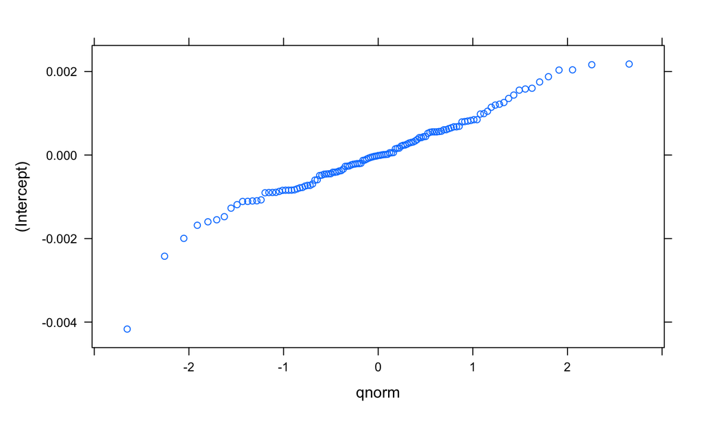

```r
plot(ranef(mod_full))
```

## Random effect

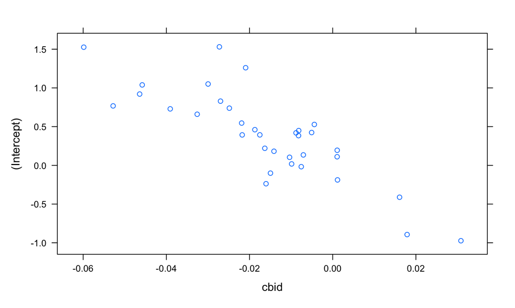

```r
plot(ranef(mod2_cue))
```

## Random effect

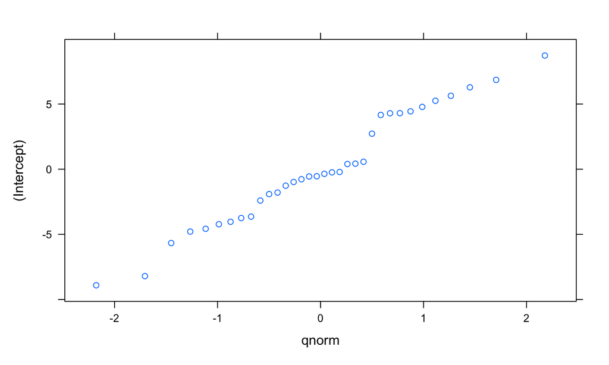

```r
plot(ranef(mod2_init))
```